# index.qmd

Author

Kitiibwa Melita Nathania

Published

December 11, 2025

# Introduction

This data was obtained from https://www.waterpointdata.org/2021/11/09/global-water-challenge-announces-the-development-of-whdx-an-open-data-exchange-to-improve-wash-in-healthcare-facilities/

under the aquaya waterTracs program.

private information such as ids were removed. in the dictionary file you will fing important cariables that may need some interpretation.

**PROJECT DESCRIPTION**

To identify the organisations that constructed the different water points

To assess their safety as drinking water points

To identify who manages the water points.

## Methods

Involved renaming a few columns as well as mutating some to give specific values. The Na values could not be removed as they would make the results meaningless.

```r
library(tidyverse)
library(here)
```

```r
raw_data <- read_csv(here::here("data/raw/CAPSTONE.csv"))
```

```r
raw_data_new <- raw_data |>
  rename(year = install_year,
        fecal_value = fecal_coliform_value,
         fecal_presence = fecal_coliform_presence,
         country_id = clean_country_id,
         country_name = clean_country_name,
         adm1 = clean_adm1,
         tech = water_tech_clean,
         management = management_clean,
         status = status_clean
  )
```

raw_new_data is the processed folder being used.

```r
raw_data_new
```

```
# A tibble: 1,000 × 25
   row_id source     report_date         status_id water_source water_tech  year
    <dbl> <chr>      <dttm>              <chr>     <chr>        <chr>      <dbl>
 1   9063 Water For… 2020-02-19 00:00:00 Yes       <NA>         Protected…    NA
 2   9223 Water For… 2005-09-07 00:00:00 No        <NA>         Protected…    NA
 3   9376 Water For… 2020-02-20 00:00:00 No        <NA>         Protected…    NA
 4  13241 Water For… 2019-03-15 00:00:00 Yes       <NA>         Protected…    NA
 5  15068 Water For… 2019-03-19 00:00:00 Yes       <NA>         Protected…    NA
 6  19412 Water For… 2005-09-07 00:00:00 Yes       <NA>         Protected…    NA
 7  31145 Water For… 2019-03-21 00:00:00 No        <NA>         Protected…    NA
 8  32000 Water For… 2020-02-20 00:00:00 Yes       <NA>         Protected…    NA
 9  39965 Water Mis… 2013-12-12 00:00:00 Unknown   <NA>         Electrica…  2012
10  41933 Water Mis… 2013-12-18 00:00:00 Unknown   <NA>         Electrica…  2008
# ℹ 990 more rows
# ℹ 18 more variables: installer <chr>, fecal_value <lgl>,
#   fecal_presence <chr>, activity_id <chr>, country_id <chr>,
#   country_name <chr>, adm1 <chr>, water_source_clean <chr>,
#   water_source_category <chr>, tech <chr>, `_facility_type` <chr>,
#   management <chr>, status <chr>, count <dbl>, updated <dttm>,
#   pay_clean <chr>, subjective_quality_clean <chr>, dataset_title <chr>
```

```r
library(gt)
library(gapminder)
```

### Results

Creating tables and figures or graphs showing the relationship between fecal contamination at water points and other factors such as the installer, the country, and the management system.

```r
summary_table_country <- raw_data_new |>
  count(country_id, fecal_presence)

summary_table_country |>
  gt() |>
   fmt_number(columns = c(country_id, fecal_presence),
             decimals = 1)
```

Table 1: Presence and absence counts in Uganda

| country_id | fecal_presence | n |
| --- | --- | --- |
| GTM | NA | 1 |
| HND | NA | 10 |
| KEN | NA | 1 |
| MEX | NA | 4 |
| UGA | Absent | 1 |
| UGA | Present | 75 |
| UGA | NA | 908 |

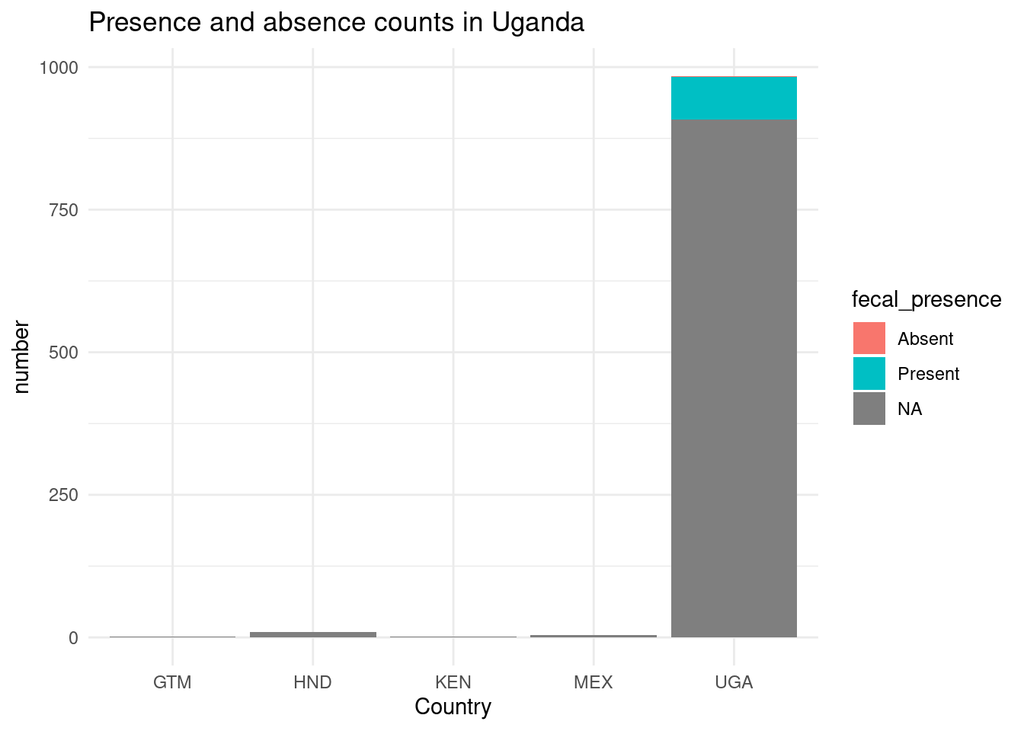

Figure 1: Graph showing presence and absence counts in Uganda

```r
ggplot(summary_table_country, aes(x = country_id, y = n,fill = fecal_presence)) +
  geom_col(position = "stack")+
  labs(title = "Presence and absence counts in Uganda", x = "Country", y = "number" ) +
  theme_minimal()
```

Figure 1 shows a graph with the presence and absence of fecal contamination at water sources.

```r
raw_data_new <- raw_data_new |>
  mutate(management = case_when(
    management == "Community Management" ~ "CM",
    management == "Other" ~ "Ot",
    management == "Other Institutional Management" ~ "OIM",
    management == "Private Operator/ Delegated Management" ~ "PO/DM",
    management == "NA" ~ "NA"
  ))
```

```r
summary_table_management <- raw_data_new |>
 count(management, fecal_presence)

summary_table_management |>
  gt() |>
   fmt_number(columns = c(management, fecal_presence),
             decimals = 1)
```

Table 2: Presence and absence counts in management systems

| management | fecal_presence | n |
| --- | --- | --- |
| CM | NA | 547 |
| OIM | NA | 60 |
| Ot | NA | 11 |
| NA | Absent | 1 |
| NA | Present | 75 |
| NA | NA | 306 |

Table 2 shows the different management systems and the presence of fecal contamination.

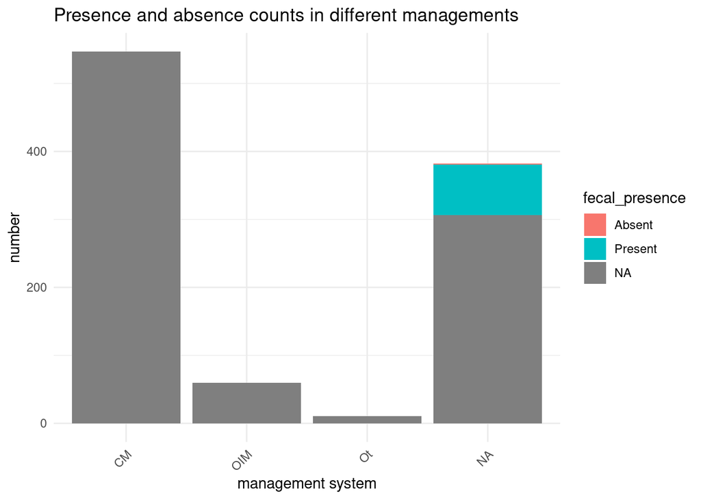

Figure 2: Graph showing presence and absence counts in management systems

```r
ggplot(summary_table_management, aes(x = management, y = n,fill = fecal_presence)) +
  geom_col(position = "stack")+
  labs(title = "Presence and absence counts in different managements", x = "management system", y = "number" ) +
  theme_minimal() +
  theme(axis.text.x = element_text(angle = 45, hjust = 1))
```

Figure 2 shows a graph that depicts results in the table.

```r
summary_table_installer <- raw_data_new |>
  count(installer, fecal_presence)

 summary_table_installer |>
  gt() |>
   fmt_number(columns = c(installer, fecal_presence),
             decimals = 1)
```

Table 3: Presence and absence counts in water sources by different installers

| installer | fecal_presence | n |
| --- | --- | --- |
| Water Mission | NA | 18 |
| World Vision | NA | 13 |
| other | NA | 1 |
| NA | Absent | 1 |
| NA | Present | 75 |
| NA | NA | 892 |

Table 3 shows the fecal presence where different organisations have installed water points.

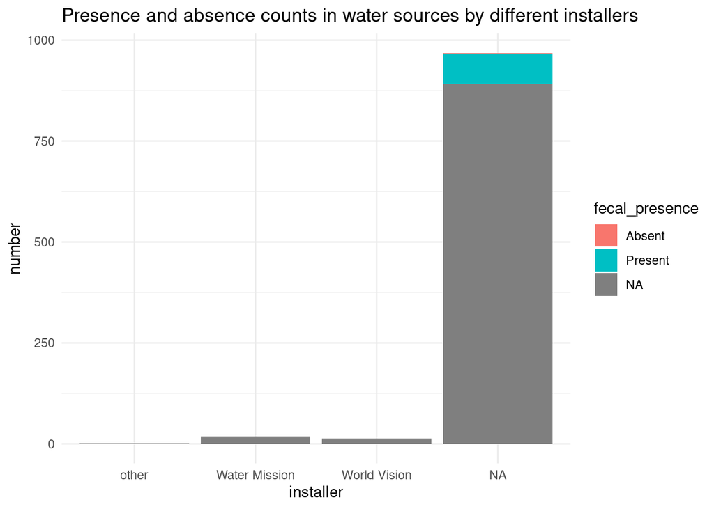

Figure 3: Graph showing presence and absence counts in water sources by different installers

```r
ggplot(summary_table_installer, aes(x = installer, y = n,fill = fecal_presence)) +
  geom_col(position = "stack")+
  labs(title = "Presence and absence counts in water sources by different installers", x = "installer", y = "number" ) +
  theme_minimal()
```

Figure 3 shows fecal contamination in a graph format.

### Conclusions

It is also prominent where other organisations that have not been recognised are in charge of constructing water points.

Uganda has been seen to have the highest water sources with fecal contamination and others are unknown.